# Reducing Fatigue in Long COVID: A Community Evidence Analysis

## 7. Recommendations: Tiered by Evidence Strength

Based on the analysis above, treatments are classified into three evidence tiers. The baseline for statistical testing is the 50% null hypothesis (a treatment no better than chance).

Strong Evidence (n>=30, p<0.05)

| Treatment | Users | Pos Rate | 95% CI | p-value | NNT vs 50% |
| --- | --- | --- | --- | --- | --- |
| magnesium | 35 | 91% | [78%, 97%] | 0.0000 | 2.4 |
| vitamin d | 35 | 74% | [58%, 86%] | 0.0060 | 4.1 |
| low dose naltrexone | 92 | 61% | [51%, 70%] | 0.0470 | 9.2 |

Moderate Evidence (n>=15 or p<0.10)

| Treatment | Users | Pos Rate | 95% CI | p-value | NNT vs 50% |
| --- | --- | --- | --- | --- | --- |
| quercetin | 14 | 93% | [69%, 99%] | 0.0018 | 2.3 |
| b vitamins | 14 | 93% | [69%, 99%] | 0.0018 | 2.3 |
| b12 | 14 | 86% | [60%, 96%] | 0.0129 | 2.8 |
| omega-3 | 12 | 83% | [55%, 95%] | 0.0386 | 3.0 |
| guanfacine | 11 | 82% | [52%, 95%] | 0.0654 | 3.1 |
| creatine | 20 | 75% | [53%, 89%] | 0.0414 | 4.0 |
| probiotics | 27 | 74% | [55%, 87%] | 0.0192 | 4.2 |
| electrolyte | 22 | 73% | [52%, 87%] | 0.0525 | 4.4 |
| melatonin | 22 | 73% | [52%, 87%] | 0.0525 | 4.4 |
| n-acetylcysteine | 18 | 72% | [49%, 88%] | 0.0963 | 4.5 |
| vitamin c | 20 | 65% | [43%, 82%] | 0.2632 | 6.7 |
| h1 antihistamine | 15 | 60% | [36%, 80%] | 0.6072 | 10.0 |
| nattokinase | 25 | 60% | [41%, 77%] | 0.4244 | 10.0 |
| tirzepatide | 21 | 57% | [37%, 76%] | 0.6636 | 14.0 |
| propranolol | 21 | 57% | [37%, 76%] | 0.6636 | 14.0 |
| coq10 | 32 | 56% | [39%, 72%] | 0.5966 | 16.0 |
| ketotifen | 18 | 56% | [34%, 75%] | 0.8145 | 18.0 |
| nicotine | 38 | 55% | [40%, 70%] | 0.6271 | 19.0 |
| cetirizine | 20 | 55% | [34%, 74%] | 0.8238 | 20.0 |
| antihistamines | 64 | 55% | [43%, 66%] | 0.5323 | 21.3 |
| famotidine | 26 | 54% | [35%, 71%] | 0.8450 | 26.0 |
| beta blocker | 16 | 50% | [28%, 72%] | 1.0000 | N/A |
| antibiotics | 15 | 40% | [20%, 64%] | 0.6072 | N/A |
| glp-1 receptor agonist | 15 | 33% | [15%, 58%] | 0.3018 | N/A |
| ssri | 27 | 22% | [11%, 41%] | 0.0059 | N/A |

Preliminary Evidence (n<15)

| Treatment | Users | Pos Rate | 95% CI | p-value | NNT vs 50% |
| --- | --- | --- | --- | --- | --- |
| taurine | 10 | 80% | [49%, 94%] | 0.1094 | 3.3 |
| ivabradine | 11 | 73% | [43%, 90%] | 0.2266 | 4.4 |
| nad | 11 | 73% | [43%, 90%] | 0.2266 | 4.4 |
| fexofenadine | 11 | 64% | [35%, 85%] | 0.5488 | 7.3 |
| mast cell stabilizer | 11 | 64% | [35%, 85%] | 0.5488 | 7.3 |
| steroids | 11 | 64% | [35%, 85%] | 0.5488 | 7.3 |
| red light therapy | 13 | 62% | [36%, 82%] | 0.5811 | 8.7 |
| methylene blue | 10 | 60% | [31%, 83%] | 0.7539 | 10.0 |
| peptide | 13 | 54% | [29%, 77%] | 1.0000 | 26.0 |
| fluvoxamine | 12 | 50% | [25%, 75%] | 1.0000 | N/A |
| h2 antihistamine | 14 | 50% | [27%, 73%] | 1.0000 | N/A |
| iron supplement | 10 | 50% | [24%, 76%] | 1.0000 | N/A |
| vagus nerve stimulation | 10 | 40% | [17%, 69%] | 0.7539 | N/A |
| l-arginine | 10 | 30% | [11%, 60%] | 0.3438 | N/A |
| cromolyn sodium | 14 | 29% | [12%, 55%] | 0.1796 | N/A |
| antidepressants | 10 | 20% | [6%, 51%] | 0.1094 | N/A |

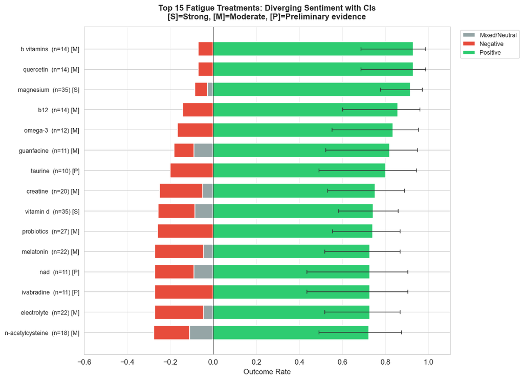

**How to read this chart.** Each bar shows the full outcome distribution for a treatment. Green extends right from center (positive), grey extends left (mixed/neutral), and red extends furthest left (negative). Error bars show 95% Wilson confidence intervals. Tags indicate evidence tier: [S] = Strong (n>=30, p<0.05), [M] = Moderate (n>=15 or p<0.10), [P] = Preliminary (n<15).

### NNT: Number Needed to Treat

For patient-facing communication, NNT translates statistical differences into practical terms: how many people need to try this treatment for 1 additional person to report benefit beyond what we would see by chance. Lower NNT = more practically useful.

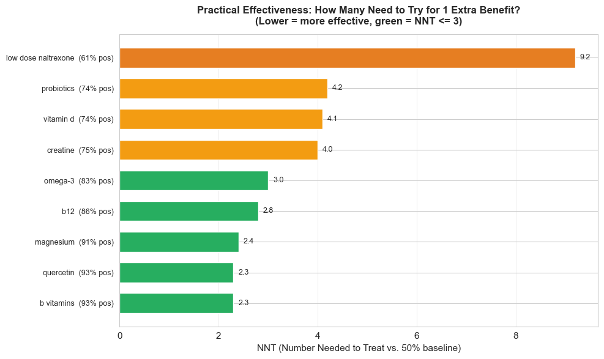

## 8. Treatment Stacking: Does More Mean Better?

Many fatigue users try multiple treatments. Does polypharmacy (trying many treatments) correlate with better outcomes? This is an observational correlation, not a causal claim. Users who try more treatments may have more severe illness, more resources, or more time since onset.

Polypharmacy and Outcome

**Spearman correlation:** rho = -0.033, p = 0.5314 -- not significant

| Tier | Users | Mean Score | Pos Rate |
| --- | --- | --- | --- |
| 1 treatment | 77 | 0.240 | 55% |
| 2-3 treatments | 93 | 0.365 | 44% |
| 4-6 treatments | 80 | 0.404 | 34% |
| 7+ treatments | 114 | 0.456 | 44% |

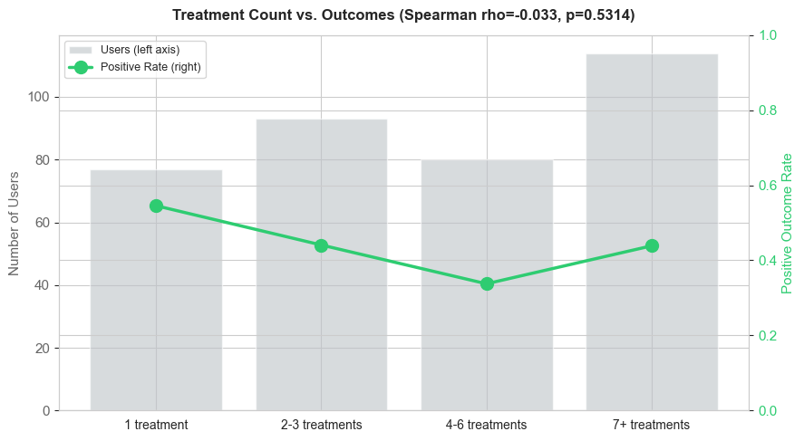

**Interpretation.** The relationship between number of treatments tried and outcomes reveals the polypharmacy pattern typical of chronic illness communities. Users trying more treatments may have worse baseline illness (driving them to try more things) or may benefit from eventually finding what works. The Spearman correlation quantifies this, but causation cannot be inferred.